# LBRAI2219 - Modélisation des systèmes biologiques

## 4.4 Relation entre les racines et la production de biomasse

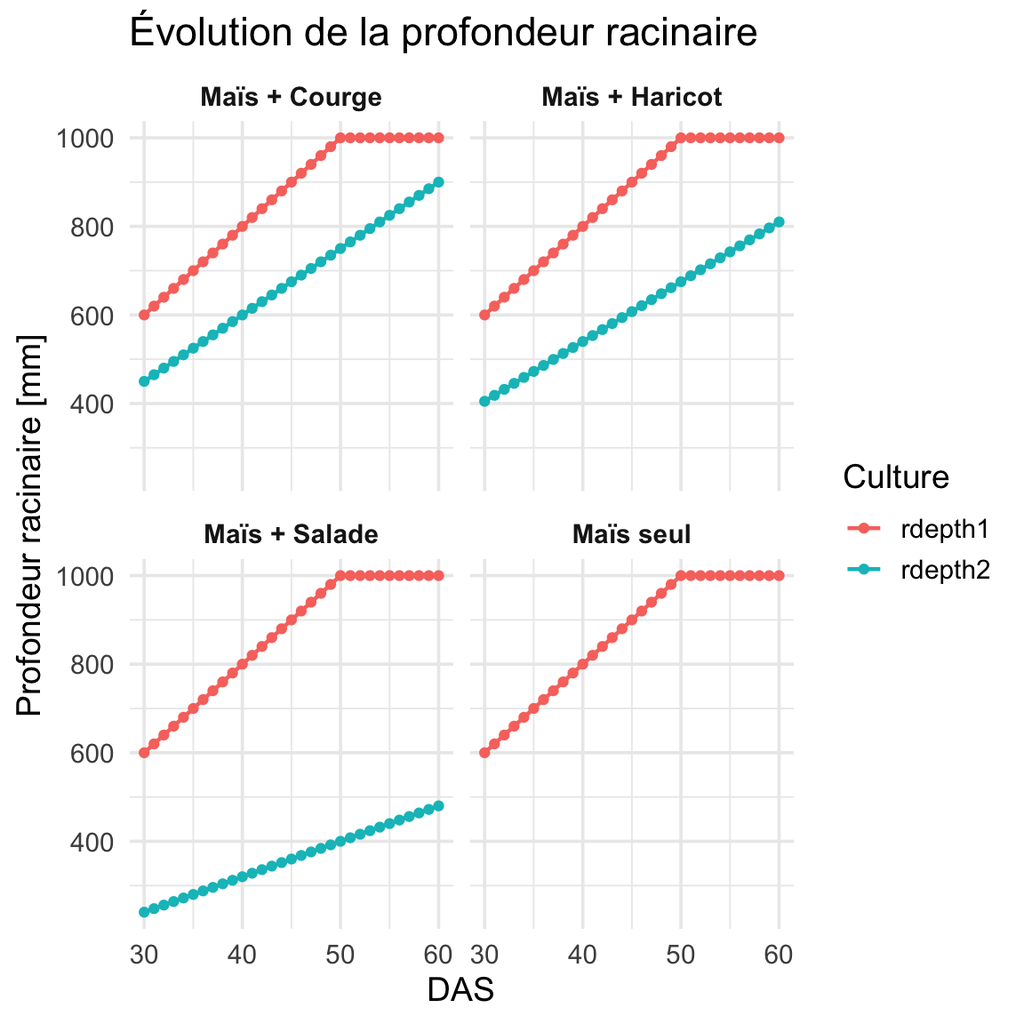

```r
# 1) Concaténation et mise en long des profondeurs racinaires
df_root_all <- bind_rows(
  resultat_mais          %>% mutate(Scenario = "Maïs seul")%>% rename(rdepth1 = rdepth),
  resultats_mais_haricot %>% mutate(Scenario = "Maïs + Haricot")%>% rename(rdepth1 = rdepth),
  resultats_mais_courge  %>% mutate(Scenario = "Maïs + Courge")%>% rename(rdepth1 = rdepth),
  resultats_mais_salade  %>% mutate(Scenario = "Maïs + Salade")%>% rename(rdepth1 = rdepth)
) %>%
  pivot_longer(
    cols            = starts_with("rdepth"),
    names_to        = "Culture",
    values_to       = "Racine_mm",
    values_drop_na  = TRUE
  )

# 2) Tracé en facettes
ggplot(df_root_all, aes(x = Jour, y = Racine_mm, color = Culture)) +
  geom_line(size = 0.8) +
  geom_point(size = 1.5) +
  facet_wrap(~ Scenario, ncol = 2) +
  labs(
    title = "Évolution de la profondeur racinaire",
    x     = "DAS",
    y     = "Profondeur racinaire [mm]",
    color = "Culture"
  ) +
  theme_minimal(base_size = 14) +
  theme(strip.text = element_text(face = "bold"))
```

Dans ce modèle minimaliste, la dynamique de développement racinaire n’est pas affectée par la présence d’une seconde espèce : chaque culture voit sa racine progresser linéairement jusqu’à une profondeur maximale (≈ 1 000 mm) définie a priori, indépendamment de la compétition interculture. En réalité, on observe que :

Cette uniformité de la croissance racinaire à la monoculture et à l’interculture résulte de l’absence, dans le modèle, de feedbacks liant compétition pour l’eau et extension racinaire. Pourtant, c’est précisément ce potentiel de profondeur qui dicte la capacité d’exploration des horizons les plus profonds et, par conséquent, l’accès à l’eau stockée dans le sol : la salade, dont le système racinaire reste très peu développé, ne peut pas puiser dans les réserves profondes et dépend presque exclusivement des premières dizaines de centimètres de terrain, tandis que maïs, courge et haricot bénéficient de l’apport hydrique plus stable des couches plus basses.